# STA106-Project2

Vincent Barletta

2023-03-02

## Part 1

In this part of the report, we are going to examine the following questions with simulated data.

What if there exist huge imbalances among sample sizes {n1,n2,..,nK }? For instance, n1 = n2 = .. = nK −1 = 100, but nK = 106.

What if the equal variance assumption is violated? That is, members of {σ21 ,σ22 ,..,σ2K } are not all equal.

What if the Normality assumption is violated?

What if you want to discover the community structures among the K samples?

### Sample Data and Expected Results for Future Simulation

Before we move forward into using these larger simulations for comparison, we will use the sample data provided in section. These are much smaller datasets, so the overall takeaway is much lower than large-scale simulations. However, we want to do this anyways to show the expected test results with non-standardized data.

From the discussion 7 PDF, we get the following dataset description:

“An economist compiled data on productivity improvements last year for a sample of firms producing electronic computing equipment. The firms were classified according to the level of their average expenditures for research and development in the past three years (low, moderate, high). The results of the study follow:”

```r
# input data
Y1 = c(7.6, 8.2, 6.8, 5.8, 6.9, 6.6, 6.3, 7.7, 6.0)
Y2 = c(6.7, 8.1, 9.4, 8.6, 7.8, 7.7, 8.9, 7.9, 8.3, 8.7, 7.1, 8.4)
Y3 = c(8.5, 9.7, 10.1, 7.8, 9.6, 9.5)
Y1=cbind(Y1,1)
Y2=cbind(Y2,2)
Y3=cbind(Y3,3)
mydata=rbind(Y1,Y2,Y3)
colnames(mydata)=c('y','level')
# convert to data.frame
mydata=as.data.frame(mydata)


# convert to factor variable
mydata$level=as.factor(mydata$level)
# Fit an Analysis of Variance Model
# function: aov(formula, data = NULL)
# formula response y~factor1 + factor2 + ...
fit1=aov(y~level,data=mydata)
# Run the ANOVA test
anova(fit1)
```

```
## Analysis of Variance Table
##
## Response: y
##           Df Sum Sq Mean Sq F value    Pr(>F)
## level      2 20.125 10.0626   15.72 4.331e-05 ***
## Residuals 24 15.362  0.6401
## ---
## Signif. codes:  0 '***' 0.001 '**' 0.01 '*' 0.05 '.' 0.1 ' ' 1
```

```r
# Construct 95% familywise confidence intervals for all
# pairwise comparisons by Tukey’s procedure.
# conf.level: family-wise confidence level
tukey=TukeyHSD(fit1, conf.level=.95)
tukey
```

```
##   Tukey multiple comparisons of means
##     95% family-wise confidence level
##
## Fit: aov(formula = y ~ level, data = mydata)
##
## $level
##         diff        lwr      upr     p adj
## 2-1 1.255556 0.37453174 2.136579 0.0043755
## 3-1 2.322222 1.26919735 3.375247 0.0000335
## 3-2 1.066667 0.06767956 2.065654 0.0347870
```

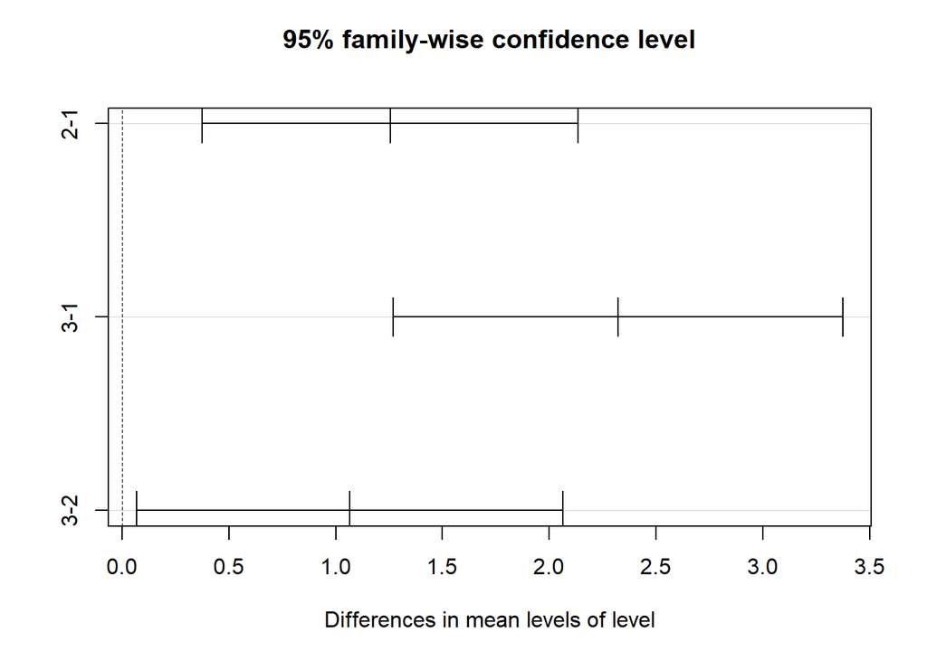

```r
plot(tukey)
```

Using a confidence level of 0.95 and alpha = 0.05, we can see that the three groups have a significant difference in mean as evidenced by our results table.

For Levels 2-1 comparison, there is a 1.255 difference with a p-value of 0.004. The null hypothesis of the Tukey-Test is that X1 - X0 = 0. As our p-value is well below the alpha of 0.05, we reject the null hypothesis and establish that the means are not equal.

We can see this additionally for Levels 3-1 and 3-2 as they hold adjusted p-values of 0.0000335 and 0.0348, respectively.

### Baseline Test

```r
K=3
# mean1=(mu1,mu2,mu3)
mean1=c(1,1,1)
# sd1=(sigma1,sigma2,sigma3)
sd1=c(1,1,3)
# samples=(n1,n2,n3)
samples=c(10000,10000,10000)

# initialize mydata
mydata=data.frame()

for(i in 1:K){
  Yi=rnorm(samples[i],mean=mean1[i],sd=sd1[i])
  data_i=cbind(Yi,i)
  mydata=rbind(mydata,data_i)
}
colnames(mydata)=c('y','level')
# convert to factor variable
mydata$level=as.factor(mydata$level)

fit1=aov(y~level,data=mydata)
anova(fit1)
```

```
## Analysis of Variance Table
##
## Response: y
##              Df Sum Sq Mean Sq F value Pr(>F)
## level         2      1  0.3431  0.0921  0.912
## Residuals 29997 111747  3.7253
```

```r
result1=anova(fit1)
result1$`Pr(>F)`[1]
```

```
## [1] 0.9120249
```

In order to get a more accurate measurement, we should either change the sample size or simulate it many times and find the overall averages. This is what we will do moving forward.

```r
# B number of replicates
B=10000
# save all p-values in the vector pvalues1
pvalues1=numeric(B)
for(b in 1:B){
  K=3
  # mean1=(mu1,mu2,mu3)
  mean1=c(1,1,1)
  # sd1=(sigma1,sigma2,sigma3)
  sd1=c(1,1,1)
  # samples=(n1,n2,n3)
  samples=c(10,10,10)

  # initialize mydata
  mydata=data.frame()

  for(i in 1:K){
    Yi=mean1[i]+rnorm(samples[i],mean=0,sd=sd1[i])
    data_i=cbind(Yi,i)
    mydata=rbind(mydata,data_i)
  }
  colnames(mydata)=c('y','level')
  # convert to factor variable
  mydata$level=as.factor(mydata$level)
  # fit anova model
  fit1=aov(y~level,data=mydata)

  # extract p-value
  result1=anova(fit1)
  pvalues1[b]=result1$`Pr(>F)`[1]

}
sum(pvalues1<0.05)/B
```

```
## [1] 0.0462
```

With the basic parameters, we receive a p-value close to alpha = 0.05. This means that the F-Test should hold up under these settings.

### What if there exist huge imbalances among sample sizes {n1,n2,..,nK }? For instance, n1 = n2 = .. = nK −1 = 100, but nK = 106.

```r
# B number of replicates
B=10000
# save all p-values in the vector pvalues1
pvalues1=numeric(B)
for(b in 1:B){
  K=3
  # mean1=(mu1,mu2,mu3)
  mean1=c(1,1,1)
  # sd1=(sigma1,sigma2,sigma3)
  sd1=c(1,1,1)
  # samples=(n1,n2,n3)
  samples=c(15,10,10)

  # initialize mydata
  mydata=data.frame()

  for(i in 1:K){
    Yi=mean1[i]+rnorm(samples[i],mean=0,sd=sd1[i])
    data_i=cbind(Yi,i)
    mydata=rbind(mydata,data_i)
  }
  colnames(mydata)=c('y','level')
  # convert to factor variable
  mydata$level=as.factor(mydata$level)
  # fit anova model
  fit1=aov(y~level,data=mydata)

  # extract p-value
  result1=anova(fit1)
  pvalues1[b]=result1$`Pr(>F)`[1]

}
sum(pvalues1<0.05)/B
```

```
## [1] 0.05
```

### What if the equal variance assumption is violated? That is, members of {σ21 ,σ22 ,..,σ2K } are not all equal.

Here, we will change σ3 to 3, and see how the results change. Let’s try this on a basic level, where we will use very large sample amounts, but only a singular simulation.

```r
K=3
# mean1=(mu1,mu2,mu3)
mean1=c(1,1,1)
# sd1=(sigma1,sigma2,sigma3)
sd1=c(1,1,3)
# samples=(n1,n2,n3)
samples=c(10000,10000,10000)

# initialize mydata
mydata=data.frame()

for(i in 1:K){
  Yi=rnorm(samples[i],mean=mean1[i],sd=sd1[i])
  data_i=cbind(Yi,i)
  mydata=rbind(mydata,data_i)
}
colnames(mydata)=c('y','level')
# convert to factor variable
mydata$level=as.factor(mydata$level)

fit1=aov(y~level,data=mydata)
anova(fit1)
```

```
## Analysis of Variance Table
##
## Response: y
##              Df Sum Sq Mean Sq F value Pr(>F)
## level         2      7  3.4737  0.9444 0.3889
## Residuals 29997 110341  3.6784
```

```r
tukey1 <- TukeyHSD(fit1)
tukey1
```

```
##   Tukey multiple comparisons of means
##     95% family-wise confidence level
##
## Fit: aov(formula = y ~ level, data = mydata)
##
## $level
##             diff         lwr        upr     p adj
## 2-1  0.031057931 -0.03251139 0.09462726 0.4863107
## 3-1 -0.002322387 -0.06589171 0.06124694 0.9959663
## 3-2 -0.033380318 -0.09694964 0.03018901 0.4350017
```

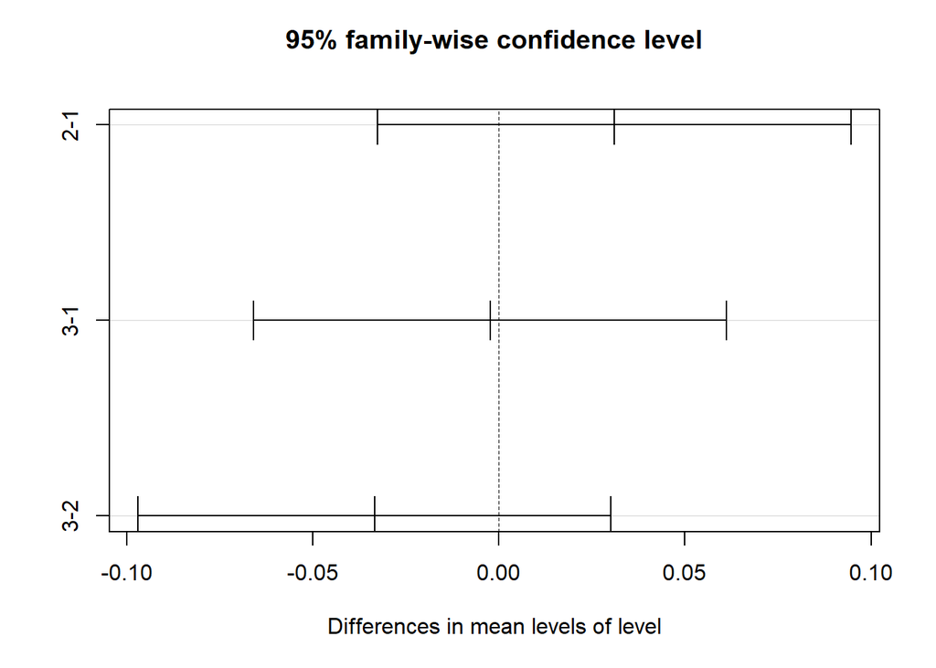

```r
plot(tukey1)
```

```r
result1=anova(fit1)
result1$`Pr(>F)`[1]
```

```
## [1] 0.3889427
```

[output not shown]

### Normality Assumption

Here, we are going to use the t-test to simulate distributions with varying degrees of freedom that are not normal, and compare them to a t-distribution that approaches normality. The higher that we increase the degrees of freedom, the closer the distribution is to normality.

We will create a T-Distribution with df = 3, df = 5, df = 10, and df = 5000 (to represent the normal distribution).

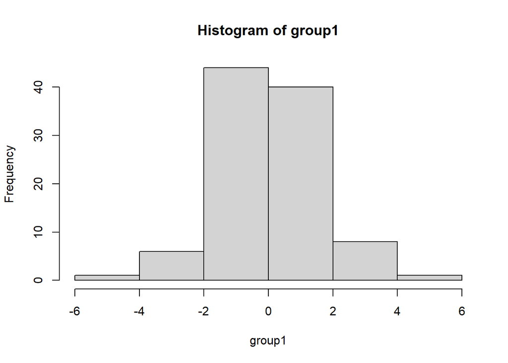

```r
group1<-rt(100,3, ncp = 0)
group2<-rt(100,5, ncp = 0)
group3<-rt(100,10, ncp = 0)
group4<-rt(1000000,5000, ncp = 0)


hist(group1)
```

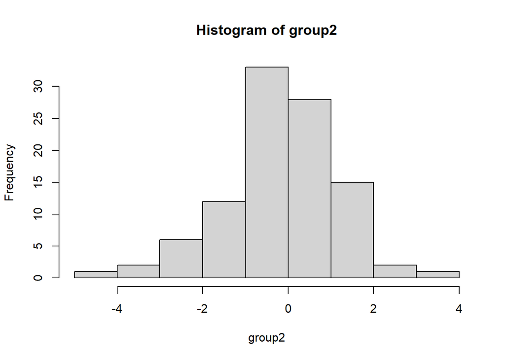

```r
hist(group2)
```

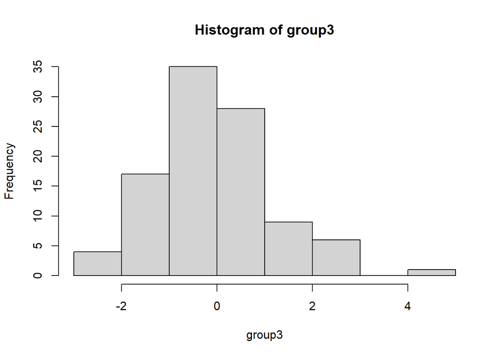

```r
hist(group3)
```

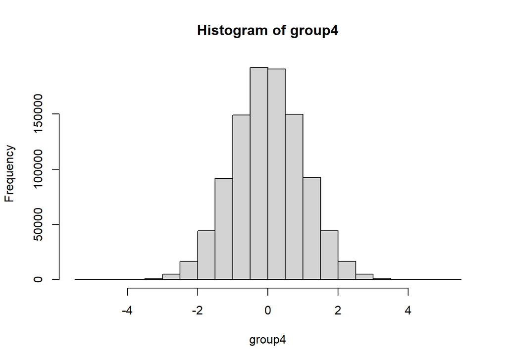

```r
hist(group4)
```

```r
data<-data.frame(
  value=c(group1,group2,group3, group4),
  group=factor(rep(c("Group 1",'Group 2', 'Group 3',"Group 4"),c(length(group1),length(group2),length(group3), length(group4))))
)

model<-aov(value~group,data = data)
summary(model)
```

```
##                Df  Sum Sq Mean Sq F value Pr(>F)
## group       3e+00       4   1.227   1.225  0.299
## Residuals   1e+06 1001774   1.002
```

```r
tukey<-TukeyHSD(model)
tukey
```

```
##   Tukey multiple comparisons of means
##     95% family-wise confidence level
##
## Fit: aov(formula = value ~ group, data = data)
##
## $group
##                        diff         lwr       upr     p adj
## Group 2-Group 1 -0.17438742 -0.53797172 0.1891969 0.6063023
## Group 3-Group 1 -0.03032083 -0.39390513 0.3332635 0.9965282
## Group 4-Group 1  0.01226746 -0.24483832 0.2693732 0.9993422
## Group 3-Group 2  0.14406659 -0.21951770 0.5076509 0.7389239
## Group 4-Group 2  0.18665488 -0.07045089 0.4437607 0.2432057
## Group 4-Group 3  0.04258829 -0.21451749 0.2996941 0.9741255
```

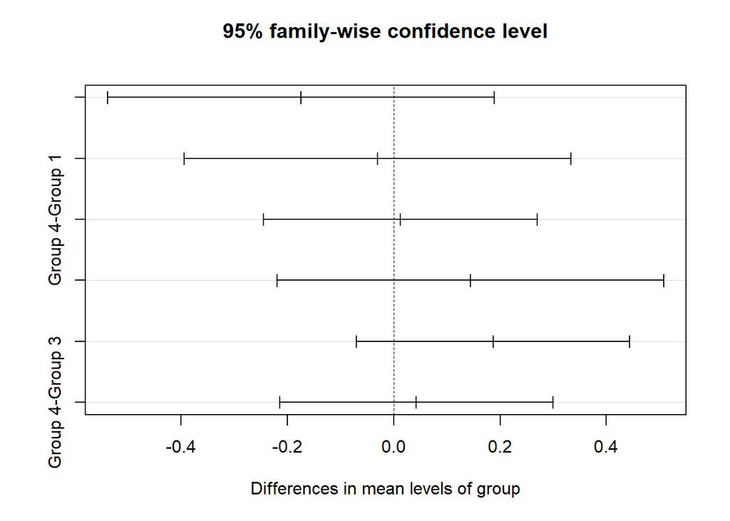

```r
plot(tukey)
```

### What if you want to discover the community structures among the K samples?

If we wanted to look at the community structures across the K samples, we can create three branching HC trees. This is done largely because we have three different K values. However, this does not mean that each value will be in their respective trees. We can see this at the end where we do print(cut_tree) and we can see that many of the values are spread across different trees.

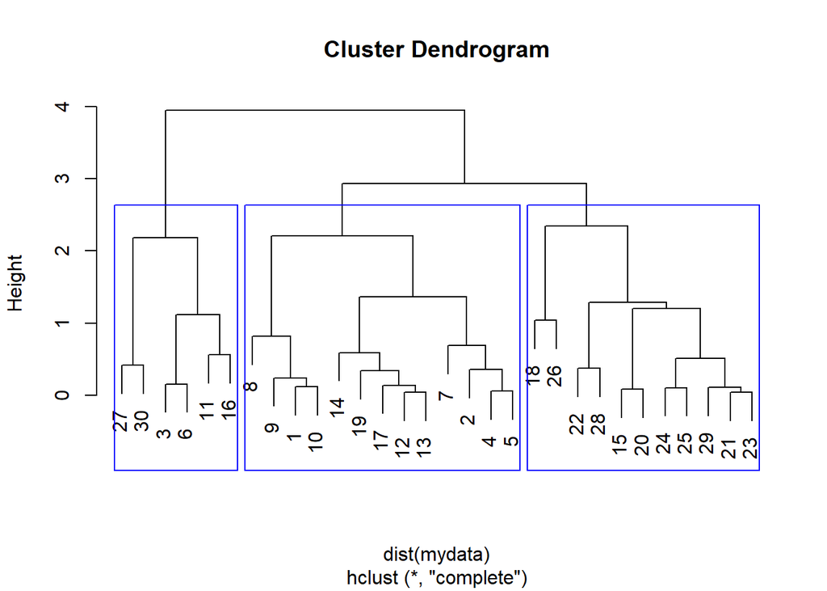

```r
#Generate three samples of normal data
set.seed(123)
K=3
mean1=c(1,1,1)
sd1=c(1,1,1)
samples=c(10,10,10)

mydata=data.frame()

for(i in 1:K){
  Yi=rnorm(samples[i],mean=mean1[i],sd=sd1[i])
  data_i=cbind(Yi,i)
  mydata=rbind(mydata,data_i)
}

#Now we can begin the process of clustering.

hcgroups <- hclust(dist(mydata))
#Cut the tree to get clusters
cut_tree <- cutree(hcgroups, k = 3)

# Plot the dendrogram with clusters highlighted
plot(hcgroups)
rect.hclust(hcgroups, k = 3, border = "blue")
```

```r
# Print the cluster membership of each sample
print(cut_tree)
```

```
##  [1] 1 1 2 1 1 2 1 1 1 1 2 1 1 1 3 2 1 3 1 3 3 3 3 3 3 3 2 3 3 2
```

## Part 2

Now that we have seen how changes in variance, normality, and sample size affect the overall means of each sample, we can begin to use the HD dataset to apply our understanding to actual data.

```r
heart= read.csv('heart_disease_health_indicators_BRFSS2015.csv',header=TRUE)
heart$HeartDiseaseorAttack=as.factor(heart$HeartDiseaseorAttack)
heart$HighBP=as.factor(heart$HighBP)
heart$HighChol=as.factor(heart$HighChol)
heart$Sex = as.factor(heart$Sex)
heart$Stroke = as.factor(heart$Stroke)
```

## Divide the entire data set into 32(= K ) samples with respect to 5 binary variables of your choices, for instance, HD, Sex, Stroke, Blood-pressure, Cholesterol. Compare the 32 BMI distributions.

After that monotonous and arduous task of splitting up everything individually, let’s look at some example graphs. The ones that we are most interested in are data1 = (0,0,0,0,0) and data14 = (1,1,1,1,1).

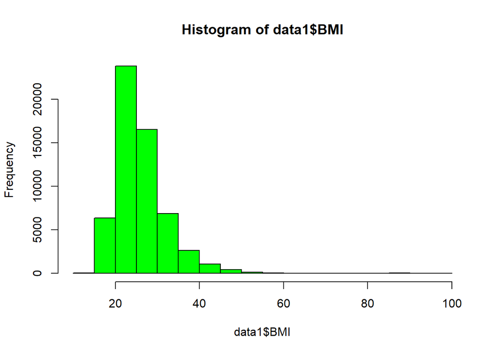

```r
hist(data1$BMI, col='green')
```

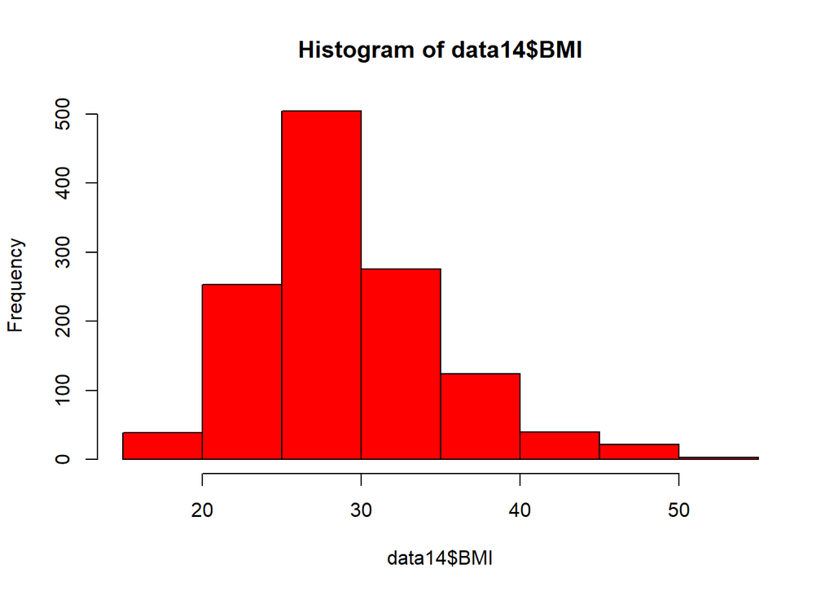

```r
hist(data14$BMI, col='red')
```

To move forward, we need to give each dataset a level and combine them all together. I will do this very monotonous work via brute force (unfortunately.) This code will blotted out for your convenience.

Let’s combine all of these datasets together into a grouped dataset. This will allow us to use facet_wrap on ggplot, which will display all 32 graphs based on which sample they came from.

[figure not shown]

```r
grouped_hd <- rbind(data1,data2,data3,data4,data5,data6,data7,data8,data9,data10,data11,data12,data13,data14,data15,data16,data17,data18,data19,data20,data21,data22,data23,data24,data25,data26,data27,data28,data29,data30,data31,data32)

library(tidyverse)

grouped_hd$Sample=as.factor(grouped_hd$Sample)
ggplot(data = grouped_hd, aes(BMI)) +
  geom_histogram(color = "steelblue") +
  facet_wrap(~ Sample)
```

[output not shown]

These translate to the following selections. Consider placement as (heart disease, HighBP, HighChol, Sex, Stroke):

1: (0,0,0,0,0) 18: (0, 1, 0, 0, 0) 19: (0 0 1 0 0) 20: (0 0 0 1 0) 24: (0 1 1 0 0) 25: (0 0 1 1 0) 29: (0 1 1 1 0) 31: (0 1 0 1 0)

Unsurprisingly, none of the most populous datasets include Heart Disease or Attack as the population of people with this attribute is relatively small.

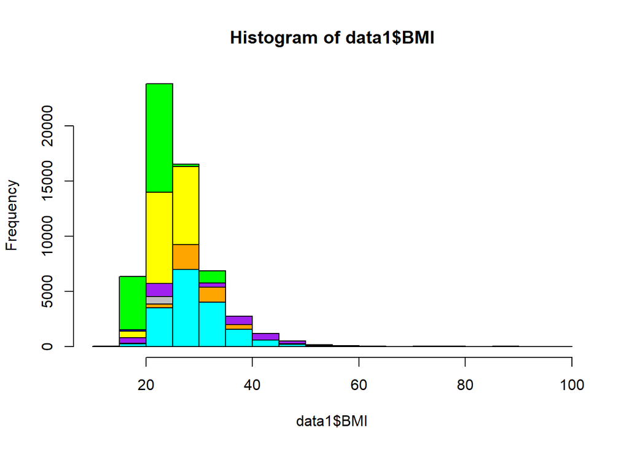

```r
hist(data1$BMI, col='green')
hist(data18$BMI, col='red', add = TRUE)
hist(data19$BMI, col='blue', add = TRUE)
hist(data20$BMI, col='yellow', add = TRUE)
hist(data24$BMI, col='purple', add = TRUE)
hist(data25$BMI, col='gray', add = TRUE)
hist(data29$BMI, col='orange', add = TRUE)
hist(data31$BMI, col='cyan', add = TRUE)
```

Here, we can see the most populous distributions tend to follow a similar distribution shape. This shape, however, is clearly not normal, has different variances and different means.

This is a great example for seeing how the Tukey-Kramer test holds up for a dataset that violates all primary assumptions.

### Perform the one-way ANOVA and Tukey-Kramer’s simultaneous pairwise comparison as if all Normality and equal-variance assumptions hold. Check whether the equal variance assumption is violated? That is, members of {σ21 ,σ22 ,..,σ2K } are not all equal.

```r
grouped_hd$Sample=as.factor(grouped_hd$Sample)

model<-aov(BMI~Sample,data = grouped_hd)
anova(model)
```

```
## Analysis of Variance Table
##
## Response: BMI
##               Df   Sum Sq Mean Sq F value    Pr(>F)
## Sample        31   563637 18181.8  438.56 < 2.2e-16 ***
## Residuals 253648 10515752    41.5
## ---
## Signif. codes:  0 '***' 0.001 '**' 0.01 '*' 0.05 '.' 0.1 ' ' 1
```

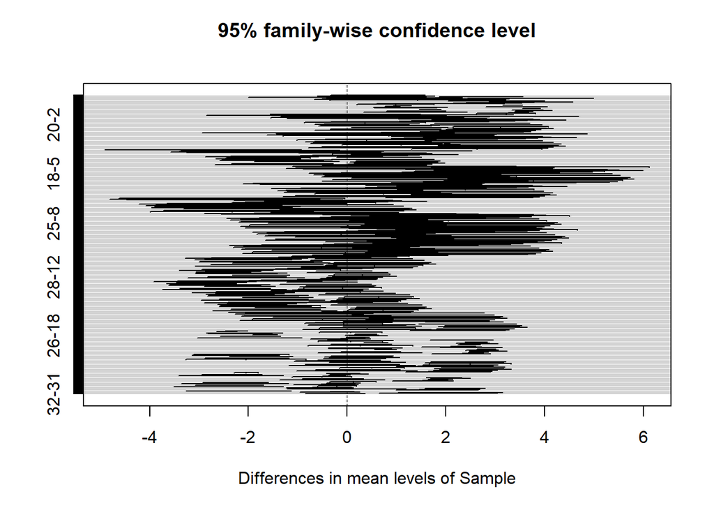

```r
tukey<-TukeyHSD(model)

plot(tukey)
```

According to our models specifics, the P-value is very low, clocking in at 2.2e-16. Therefore, we can confirm that across all models, the means are very different, and we can reject the null hypothesis.

Let’s dive further into the graph’s output and look at some individual differences between the datasets.

This is a pretty muddled graph. We want to look at the graphs that have the largest difference in mean and some with the smallest difference in mean. We will choose an arbitrary cutoff point of 3.8 for the largest difference

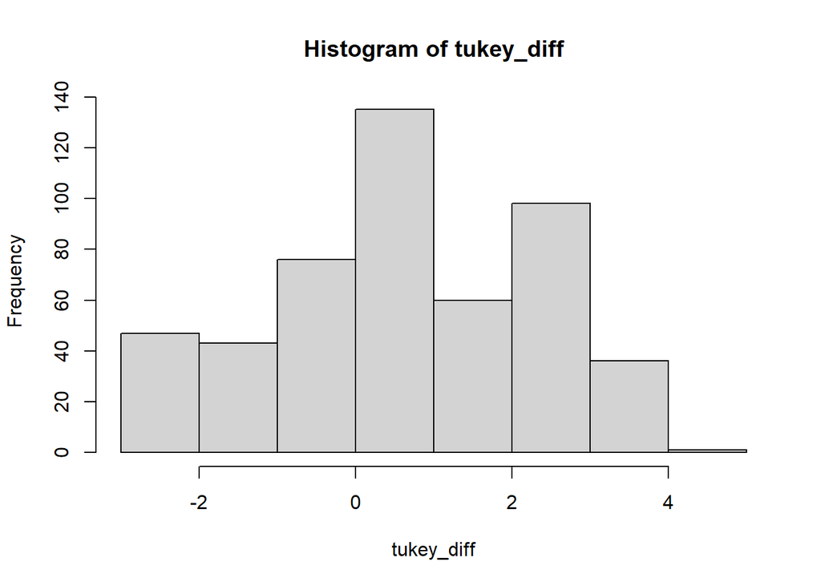

```r
tukey_diff <-tukey$Sample[,1]
hist(tukey_diff)
```

```r
diff_greater_than_3.8 <- subset(tukey_diff, tukey_diff > 3.8)
diff_greater_than_3.8
```

```
##     13-1      7-5     13-5     24-5     26-5     27-5
## 3.867306 3.914682 4.068284 3.935559 3.856998 3.979991
```

```r
mean(data5$BMI)
```

```
## [1] 26.27869
```

```r
nrow(data5)
```

```
## [1] 183
```

On the other side, we can look at maximum negative differences, choosing 2.6 as a cutoff point.

```r
diff_less_than <- subset(tukey_diff, tukey_diff < -2.6)
diff_less_than
```

```
##       5-4       9-7      17-7      19-7      20-7     17-13     19-13     20-13
## -2.914357 -2.678664 -2.729660 -2.601590 -2.794854 -2.883262 -2.755192 -2.948456
##     23-13
## -2.685650
```

Here, we can see that 7 and 13 are outlier graphs. Dataset 7 has HD, HighBP, and Stroke. Dataset 13 has HD, HighBP, HighChol, and Stroke

```r
mean(data7$BMI)
```

```
## [1] 30.19337
```

```r
mean(data13$BMI)
```

```
## [1] 30.34697
```

These two have very high BMIs, so it is unsurprising that they have larger distance away from a multitude of datasets from healthier patients.

Finally, we will now check if the variances are equal across all samples or not. For this, we will use the Brown-Forsythe Test to check the difference between the variances in each group.

```r
grouped_hd_var <- grouped_hd %>%
  group_by(Sample) %>%
  summarize(var=var(BMI))

grouped_hd_var
```

```
## # A tibble: 32 x 2
##    Sample   var
##    <fct>  <dbl>
##  1 1       41.6
##  2 2       49.9
##  3 3       32.0
##  4 4       60.5
##  5 5       42.0
##  6 6       31.8
##  7 7       71.9
##  8 8       40.9
##  9 9       50.0
## 10 10      25.1
## # ... with 22 more rows
```

```r
bf.test(BMI ~ Sample, data = grouped_hd)
```

```
##
##   Brown-Forsythe Test (alpha = 0.05)
## -------------------------------------------------------------
##   data : BMI and Sample
##
##   statistic  : 417.5365
##   num df     : 31
##   denom df   : 20155.49
##   p.value    : 0
##
##   Result     : Difference is statistically significant.
## -------------------------------------------------------------
```

Simply by looking at the list of variances, we can see quite a large difference between each sample. Upon further testing, we can see that this is absolutely correct, and that there is a statistically significant difference between each.

### Check whether the Normality assumption is violated?

To check for normality, we can use a QQ-Plot and see if it falls along the general line we would expect from a normal distribution. By simply looking at the graphs before, we know that BMI is not normally distributed, but we can see all of the data placed along this axis for reference.

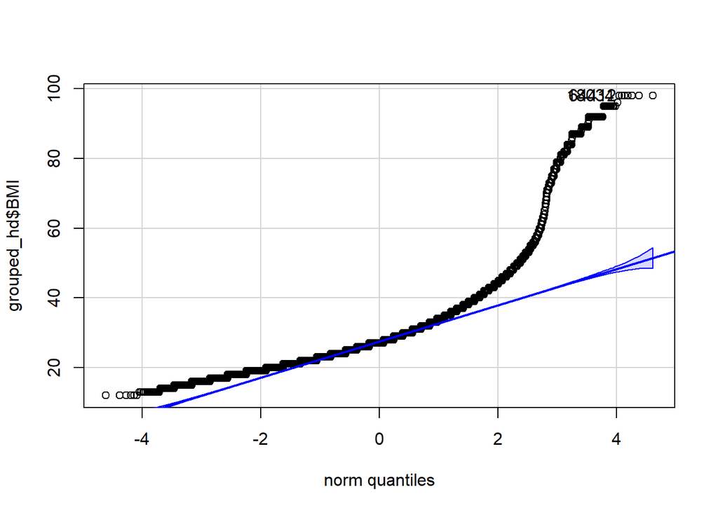

```
## [1] 18034 64412
```

```r
qqPlot(grouped_hd$BMI)
```

Here, we clearly see that the data largely deviates from the normal QQ line that a normal distribution is expected to follow. Therefore, as we expected, the normality assumption is violated.

### Construct HC-tree to discover the community structures among the K samples?

Here, we will use the contingency table code provided to us in section to calculate the HC-tree and see the likeness between the different samples. Creating this histogram allows us to pool all of the data across each sample and get a more accurate estimation of closeness between the samples.

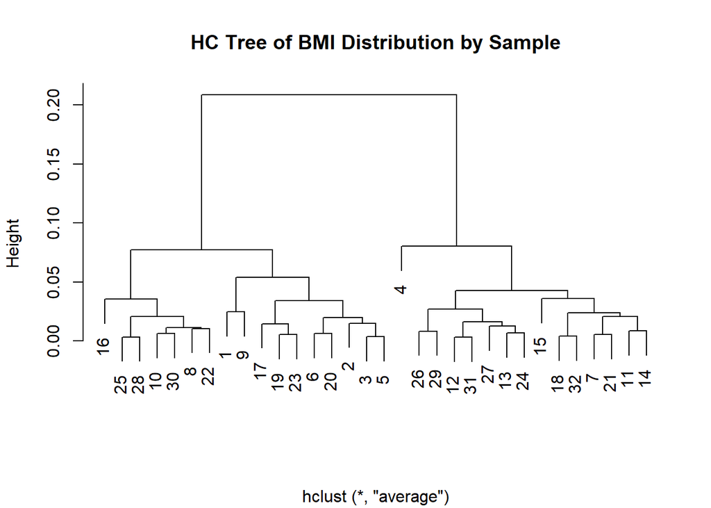

```r
Build_contigencytable=function(data,group,variable,bins=10,proportion=FALSE){
  table1=NULL
  # create break points for the following histograms
  # from minimum to maximum with equal distance
  ax=seq(min(data[,variable]),max(data[,variable]),length.out=bins+1)
  # Save histogram data
  list_group=unique(data[,group])
  for(i in list_group){
    hg1=hist(data[data[,group]==i,variable], breaks = ax,plot = FALSE)
    table1=rbind(table1,hg1$counts)
  }
  rownames(table1)=list_group
  colnames(table1)=1:ncol(table1)
  # calculate row sum and combine it  with the current table
  table1=cbind(table1, 'Total'=apply(table1,1,sum))
  # calculate column sum and combine it  with the current table
  table1=rbind(table1, 'Total'=apply(table1,2,sum))

  if(proportion){
    # convert to proportions
    n_col=ncol(table1)
    for(i in 1:nrow(table1)){
      table1[i,]=table1[i,]/table1[i,n_col]
    }
  }
  table1
}

# build proportion contigency table for the histogram of Petal.Length with group factor "Species"
BMI_table <- Build_contigencytable(grouped_hd,"Sample","BMI",5,TRUE)
# Remove the total row so that it does not appear in our Tree Diagram
BMI_table <- BMI_table[1:32,]
df1=BMI_table[,1:5]

clusters <- hclust(dist(df1), method = 'average')
plot(clusters,xlab='',main='HC Tree of BMI Distribution by Sample')
```

Now, we want to add clusters to our plot. We will use the provided code for the Gap Statistic Method.

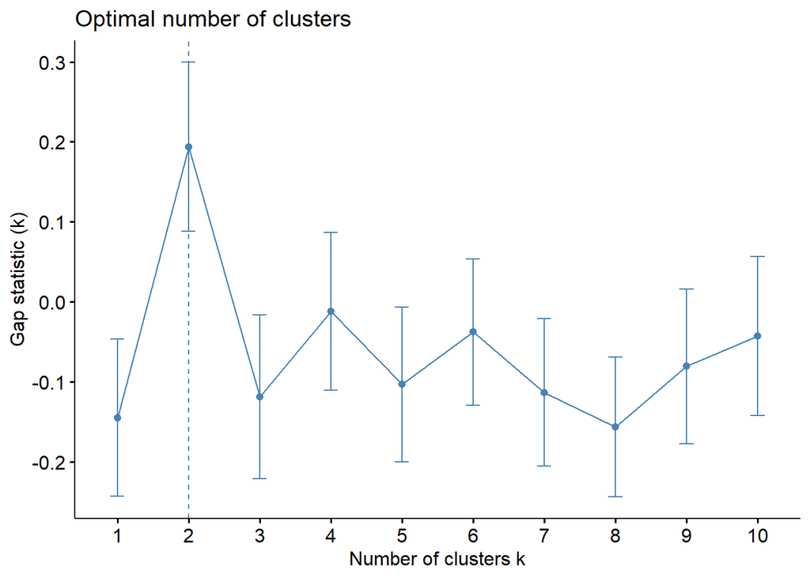

```r
gap_stat <- clusGap(df1, FUN = hcut, K.max = 10,hc_method = "average")
fviz_gap_stat(gap_stat)
```

We therefore declare that 2 clusters is the optimal amount for our HC tree. At last, let’s add this to our graph.

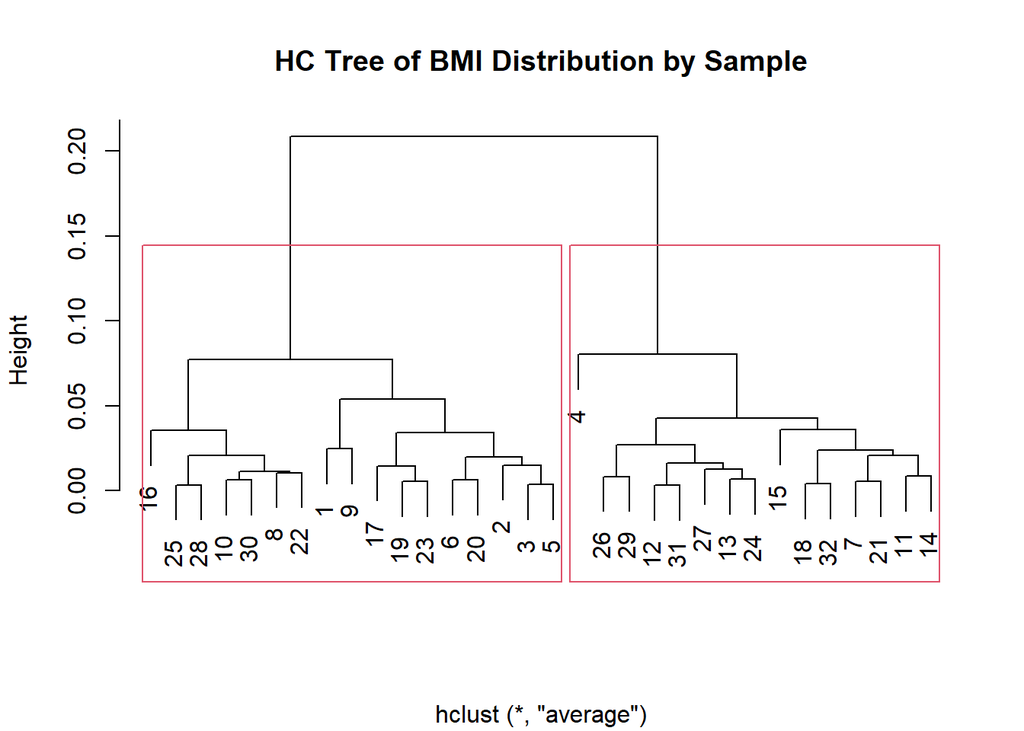

```r
plot(clusters,xlab='',main='HC Tree of BMI Distribution by Sample')
clusterCut <- cutree(clusters, 2)
# plot the tree
rect.hclust(clusters, k=2)
```

Let’s do a minor level of verification to ensure that this is accurate. We will check the lowest base level pairs and see if they are very similar, and also check two branches very far from each other.

```r
mean(data11$BMI)
```

```
## [1] 29.50401
```

```r
mean(data14$BMI)
```

```
## [1] 29.56939
```

```r
mean(data5$BMI)
```

```
## [1] 26.27869
```

Here, we see that the two bottom right branches are very close together. In comparison to Branch #5, which is in the bottom right of the left cluster, there is a relatively large disparity. We can now ensure that the communities are accurately placed based on the contingency table and averaging mechanism of the clusters.

## Conclusion

Overall, throughout our initial simulations, we saw that while using K = 3 classes, changing the sample size and variance does not yield major changes to the means across samples. This is confirmed by high p-values during individual simulation, telling us that we cannot reject the null hypotheses that the means are equal.

Under mass simulation of B = 10,000, the ratio being close to 0.05 indicates that the F-Test holds true for our initial results and that we still fail to reject the null hypothesis.

Once we move to the Heart Disease dataset, we can see some of these notions in practice. Largely, our analysis shows that the means are very different across each sample, primarily because BMI is not normally distributed. This is shown in the QQ-plot, as it deviates greatly from the normality range. The variance is also very different, as shown by the Brown-Forsythe test we conducted.

While some samples vary greatly in mean, there are also many that are quite close. This is displayed perfectly by our HC-tree, which displays the distances between each mean. We calculated the optimal number of clusters, and determined that they can fit into two main clusters.